# CS 498 AML Homework 5

## Question 1 - Music

```r
music <- read_csv('./music.csv')
music.num_features = dim(music)[2]-2
music["latitude"] <- music["latitude"] + 90
music["longitude"] <- music["longitude"] + 180
```

A small angle transformation was required here to make the $latitude$ and $longitude$ values non-negative. Box-Cox requires the response variables to be non-negative.

### Latitude

**(a)** Fit a linear model

```r
lat.lm <- lm(latitude ~ . - longitude, data = music)
```

```
## [1] "The R^2 value is"  "0.290022599470525"
```

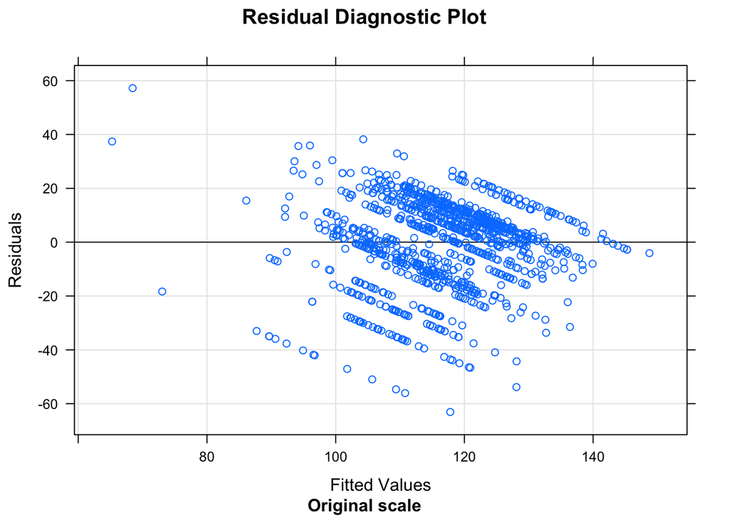

The $R^2$ value tells us how well the regression explains the training data. In this case our $R^2$ estimation is rather low (approx. $0.29$), explicitely telling us that we should consider a better model or perhaps a transformation. Indeed, The Box-Cox transformation is a method that can search for a power transformation of the dependent variable that improves the regression. One searches for a value of $\lambda$ that makes residuals look most like a normal distribution.

**(b)** Box-Cox

```r
lat.bc_info = boxcox(lat.lm, lambda=seq(-1,5))
```

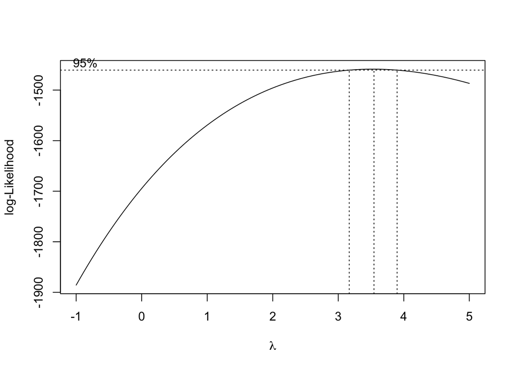

```r
lat.bc_lambda = lat.bc_info$x[which.max(lat.bc_info$y)] #selecting best lambda
lat.lm_lambda = lm( latitude^lat.bc_lambda ~ . - longitude, data=music)
# now let us see if we have improved our model and Rsquared value
```

Above, different powers ($\lambda$) are teseted on the response variable and the one with the highest log-likelihood is chosen.

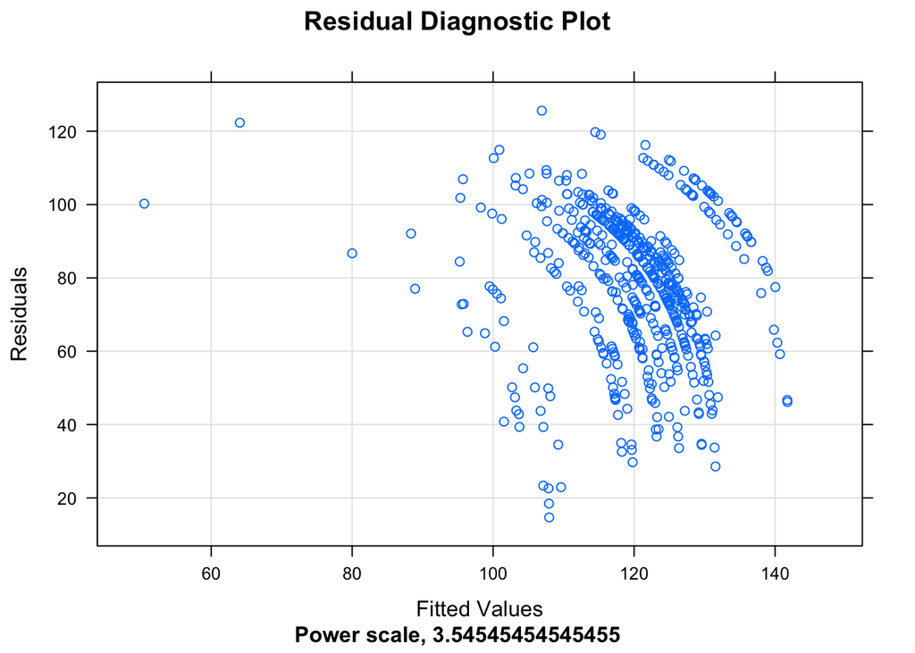

```
## [1] "The new R^2 value is" "0.319712643517031"
```

```
## [1] "The Box-Cox optimal lambda is" "3.54545454545455"
```

Looking at the residuals vs fitted graph (transformed back to the orignal power), there appears to be a pattern. We expect the residuals to be normally distirbuted, this should make us question out assumption of homoscedasticity.

**(c)** Regularization

```r
# Lasso L1
lat.l1 = cv.glmnet(as.matrix(music[1:music.num_features]),
                as.matrix(music["latitude"]^lat.bc_lambda),
                alpha=1)
# Ridge L2
lat.l2 = cv.glmnet(as.matrix(music[1:music.num_features]),
                   as.matrix(music["latitude"]^lat.bc_lambda),
                   alpha=0)
```

```
## [1] "The minimum log lambda for Lasso L1 is"
## [2] "11.4854913520492"
```

```
## [1] "The minimum log lambda for Ridge L2 is"
## [2] "14.0206607978709"
```

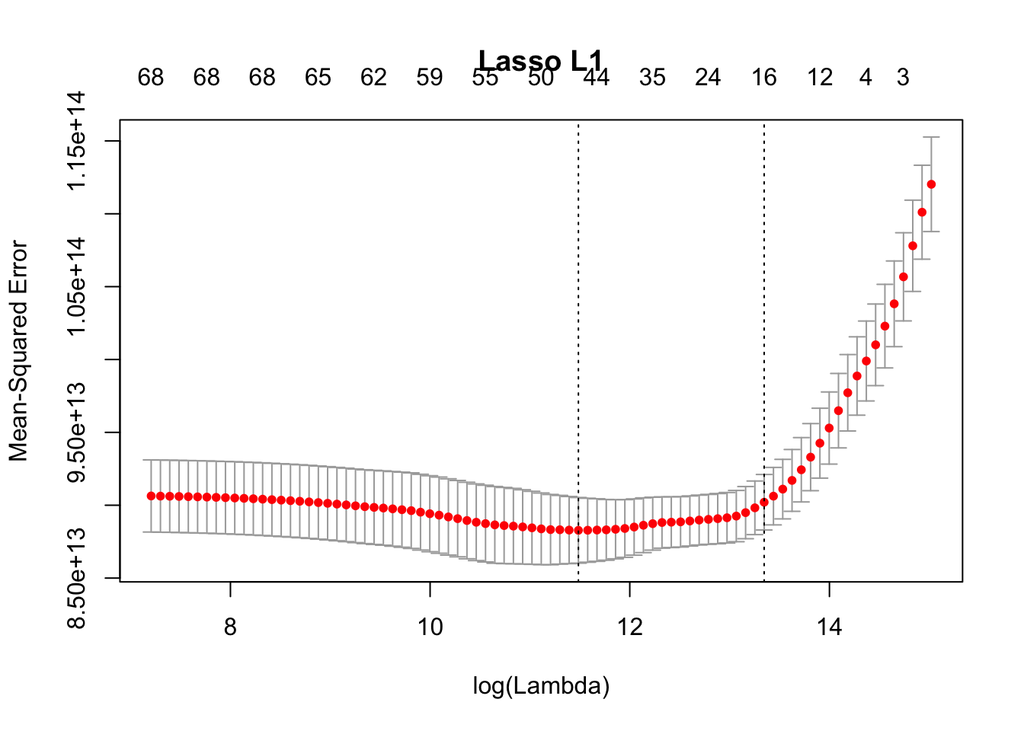

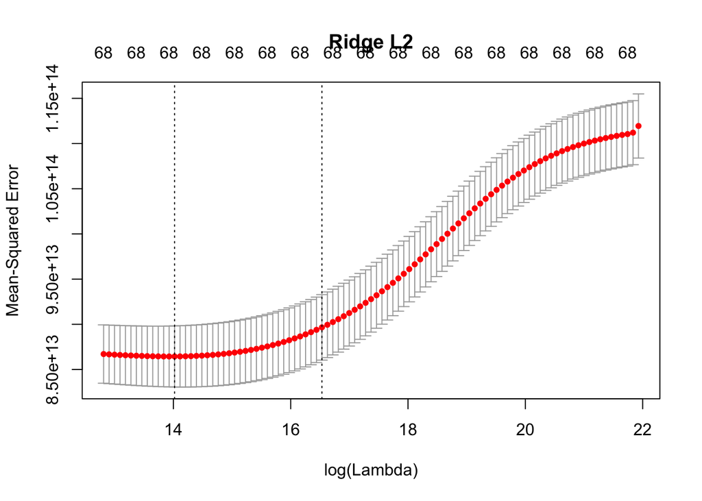

```r
plot(log(lat.l1$lambda),
     (lat.l1$cvm)^(1/lat.bc_lambda),
     pch=19,
     col="red",
     xlab="log(Lambda)",
     ylab="CVM",
     main="MSE as function of log(Lambda)",
     sub = toString(c("Lasso L1", "Power scale", lat.bc_lambda)))
points(log(lat.l2$lambda),
       (lat.l2$cvm)^(1/lat.bc_lambda),
       pch=19,
       col="blue")
legend("bottomright", legend=c("alpha=1 L1","alpha=0 L2"), pch=10, col=c("red", "blue"))
```

[output not shown]

### Longitude

**(a)** Fit a linear model

```r
lon.lm <- lm(longitude ~ . - latitude, data = music)
```

```
## [1] "The R^2 value is"  "0.335536695339324"
```

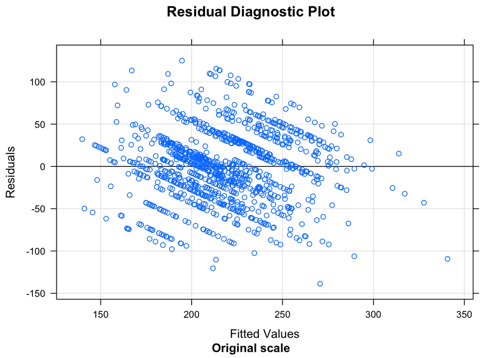

**(b)** Box-Cox

```r
lon.bc_info = boxcox(lon.lm)
```

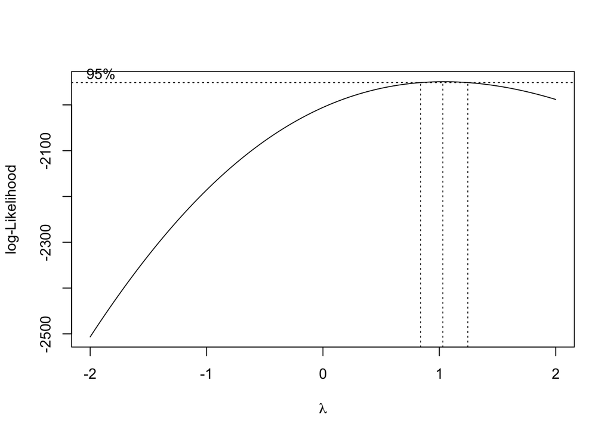

```r
lon.bc_lambda = lon.bc_info$x[which.max(lon.bc_info$y)]
lon.lm_lambda = lm(longitude^lon.bc_lambda ~ . - latitude, data=music)
```

```
## [1] "The new R^2 value is" "0.335673855400167"
```

```
## [1] "The Box-Cox optimal lambda is" "1.03030303030303"
```

[figure not shown]

The Box-Cox transformation does not help becuase the residuals are not really effected. Since the optimal $\lambda$ found by Box-Cox is about $1$, we don’t expect this to do a lot. Since $\lambda$ is about $1$, we will use the simpler model.

**(c)** Regularization

```r
# Lasso L1
lon.l1 = cv.glmnet(as.matrix(music[1:music.num_features]),
                as.matrix(music["longitude"]),
                alpha=1)
# Ridge L2
lon.l2 = cv.glmnet(as.matrix(music[1:music.num_features]),
                as.matrix(music["longitude"]^lon.bc_lambda),
                alpha=0)
```

```
## [1] "The minimum log(lambda) for Lasso L1 is"
## [2] "-0.858034758901068"
```

```
## [1] "the minimum log(lambda) for Ridge L2 is"
## [2] "1.59231325439354"
```

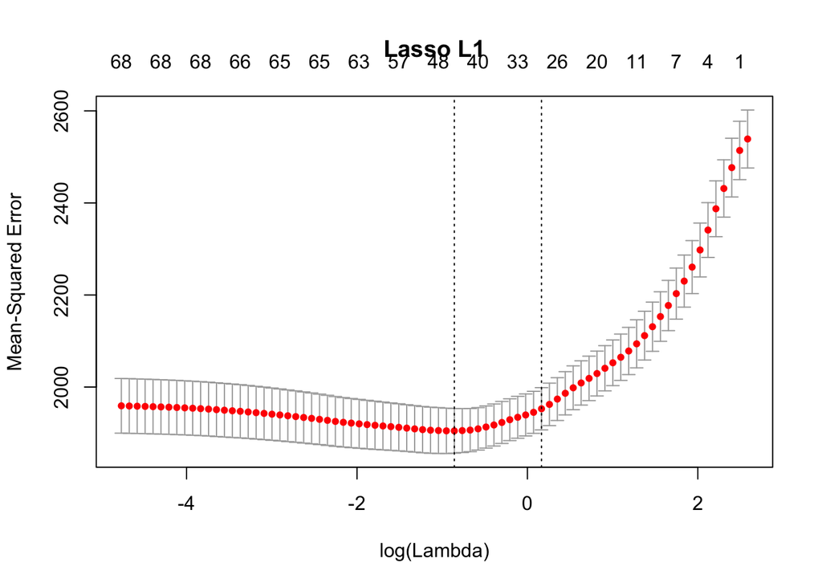

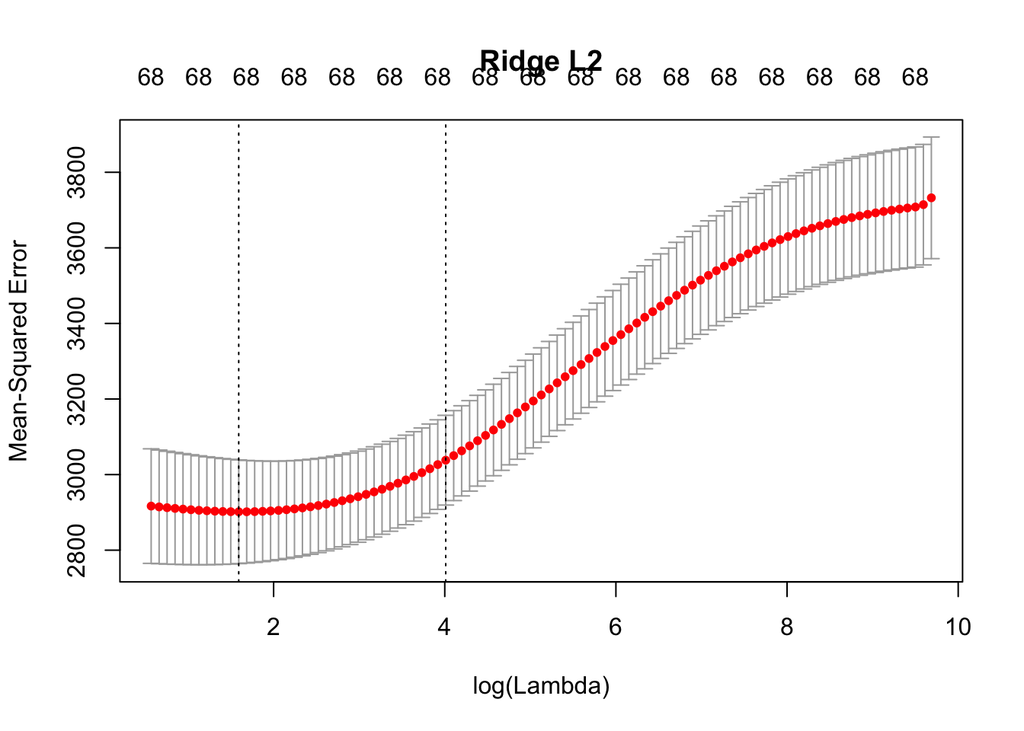

```r
plot(log(lat.l1$lambda),lat.l1$cvm,pch=19,col="red",xlab="log(Lambda)",ylab=lat.l1$name)
points(log(lat.l2$lambda),lat.l2$cvm,pch=19,col="grey")
legend("topleft",legend=c("alpha= 1 L1","alpha= 1 L2"),pch=19,col=c("red","grey"))
```

[output not shown]

## Question 2 - Default

```r
default <- read_csv('./default.csv')
default.num_features = dim(default)[2]-1
```

**(a)** Fit a linear model

```r
default.lm_cv <- cv.glmnet(as.matrix(default[1:default.num_features]),
                        as.matrix(default["default"]),
                        type.measure = "auc",
                        family="binomial")
default.lm_cv.lasso <- cv.glmnet(as.matrix(default[1:default.num_features]),
                        as.matrix(default["default"]),
                        family="binomial",
                        type.measure = "auc",
                        alpha=1)
default.lm_cv.ridge <- cv.glmnet(as.matrix(default[1:default.num_features]),
                        as.matrix(default["default"]),
                        family="binomial",
                        type.measure = "auc",
                        alpha=0)
default.lm_cv.elastic<- cv.glmnet(as.matrix(default[1:default.num_features]),
                        as.matrix(default["default"]),
                        family="binomial",
                        type.measure = "auc",
                        alpha=0.5)
plot(default.lm_cv)
plot(default.lm_cv.lasso, sub="Lasso")
plot(default.lm_cv.ridge, sub="Ridge")
plot(default.lm_cv.elastic,sub="Elasticnet")
```

[output not shown]

## Question 3 - Cancer

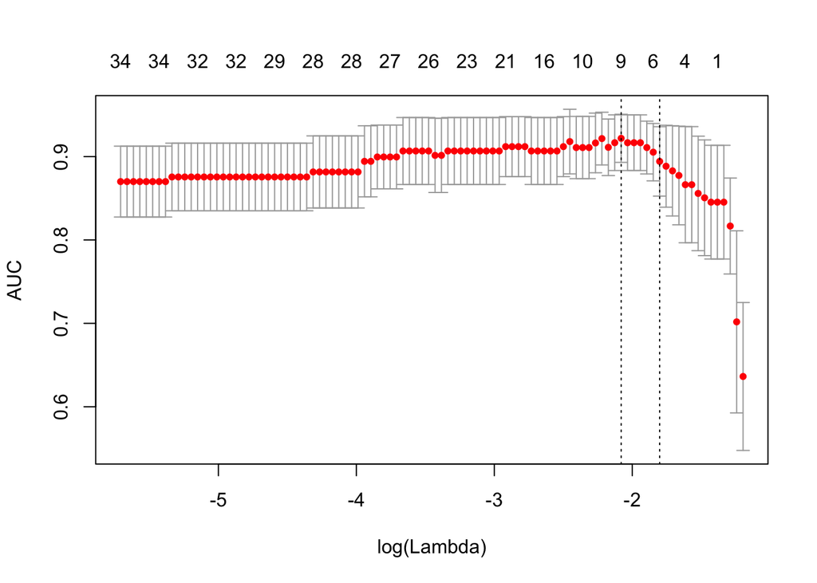

```r
cancer <- read_csv('./cancer.csv', col_names = FALSE)
cancer.num_features = dim(cancer)[2]-1
colnames(cancer)[2001] <- 'state'

# AUC
cancer.lm_cv.lasso.auc <- cv.glmnet(model.matrix(~ ., data=cancer[1:cancer.num_features]),
                        cancer$state,
                        family="binomial",
                        type.measure = "auc",
                        alpha=1, nfolds=5)
plot(cancer.lm_cv.lasso.auc)
```

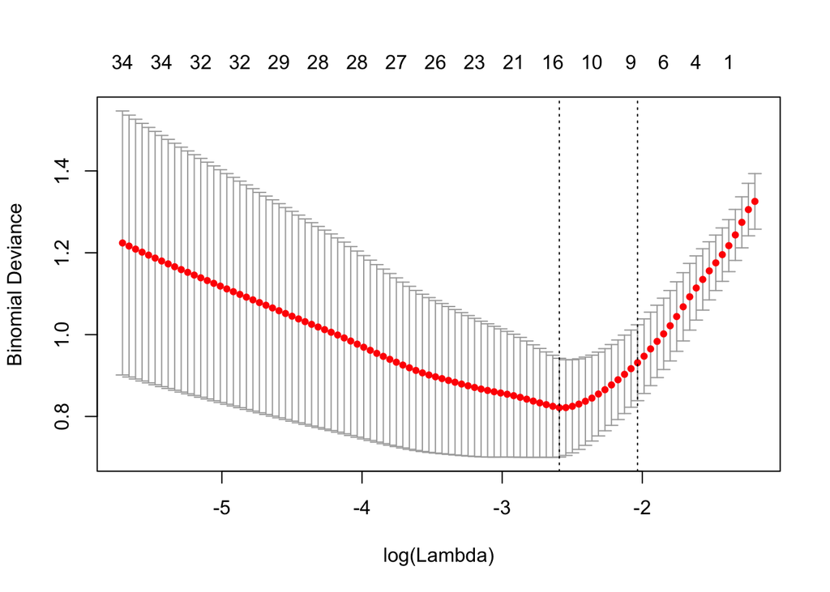

```r
# Deviance
cancer.lm_cv.lasso.deviance <- cv.glmnet(model.matrix(~ ., data=cancer[1:cancer.num_features]),
                        cancer$state,
                        family="binomial",
                        type.measure = "deviance",
                        alpha=1)
plot(cancer.lm_cv.lasso.deviance)
```